# ARIMA

An *ARIMA* model is an *Integrated Autoregressive Moving Average Process*. It is a univariate model that is similar to ARMA but can deal with non-stationarity. * p = AR polynomial: variable of interest is regressed on its own prior values * d = Integrated part: Indicates that the data values have been rteplaced with the *difference* between their values and the previous values (can be more than once) * q = MA polynomial: variable of interest depends linearly on the current and various past values of a stochastic term.

When two out of 3 terms are zeros, the model can be referred to as AR, I, or MA. E.g, * ARIMA(1, 0, 0) = AR(1) * ARIMA(0, 1, 0) = I(1) * ARIMA(0, 0, 1) = MA(1)

### ARIMA(0, 0, 0)

A *White noise model. Nothing can be used to predict the future outcome.

```r
library(FitAR)
library(forecast)
library(tseries)
library(gplots)
library(aTSA)
library(astsa)
library(lmtest)
foodcorp.df <-read.csv("SLIM0405DataSeries.csv")
```

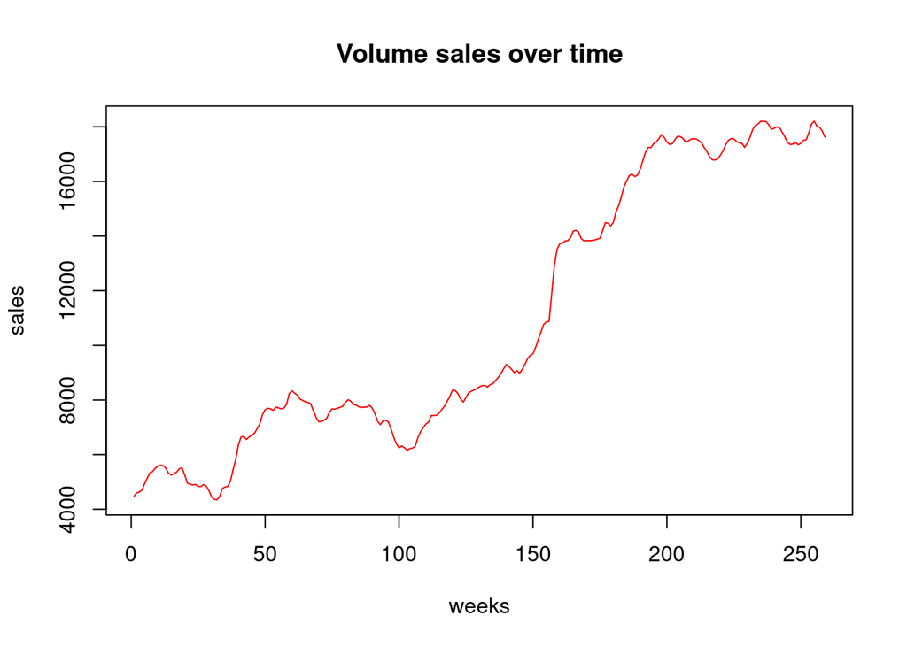

```r
plot(foodcorp.df[,c(1)],foodcorp.df[,c(8)], type="l", col="red", lwd=1, xlab="weeks", ylab="sales", main="Volume sales over time")
```

### ADF test for stationarity

```r
adf.test(foodcorp.df[,c(8)], nlag = 4, output = TRUE)
```

```
## Augmented Dickey-Fuller Test
## alternative: stationary
##
## Type 1: no drift no trend
##      lag  ADF p.value
## [1,]   0 4.23   0.990
## [2,]   1 1.43   0.961
## [3,]   2 2.08   0.990
## [4,]   3 1.83   0.983
## Type 2: with drift no trend
##      lag    ADF p.value
## [1,]   0 -0.137   0.940
## [2,]   1 -0.644   0.822
## [3,]   2 -0.484   0.878
## [4,]   3 -0.499   0.872
## Type 3: with drift and trend
##      lag    ADF p.value
## [1,]   0 -0.961   0.944
## [2,]   1 -1.965   0.591
## [3,]   2 -1.513   0.781
## [4,]   3 -1.643   0.726
## ----
## Note: in fact, p.value = 0.01 means p.value <= 0.01
```

### PP test for stationarity

```r
pp.test(foodcorp.df[,c(8)], output = TRUE)
```

```
## Phillips-Perron Unit Root Test
## alternative: stationary
##
## Type 1: no drift no trend
##  lag Z_rho p.value
##    5 0.951   0.902
## -----
##  Type 2: with drift no trend
##  lag  Z_rho p.value
##    5 -0.362   0.934
## -----
##  Type 3: with drift and trend
##  lag Z_rho p.value
##    5 -4.27   0.861
## ---------------
## Note: p-value = 0.01 means p.value <= 0.01
```

### ACF

Empirical ACF decays only very slowly to zero

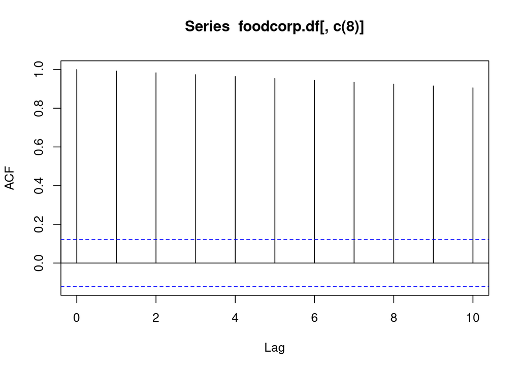

```r
foodacf = acf(foodcorp.df[,c(8)], lag.max = 10)
```

### PACF

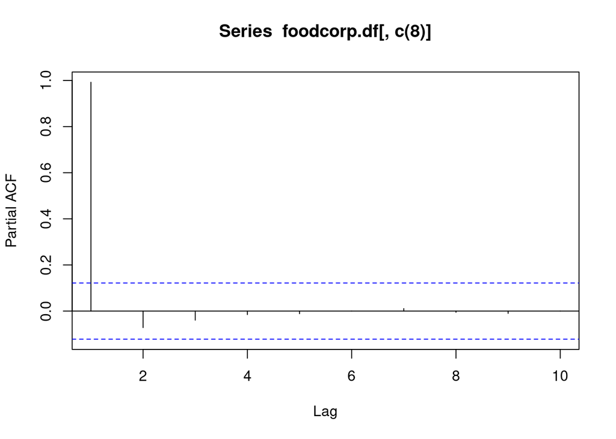

```r
foodpacf = pacf(foodcorp.df[,c(8)], lag.max = 10)
```

### Differencing first-order

```r
foodsel = foodcorp.df[,c(8)]
fooddif = diff(foodsel)
```

### ADF test after differencing

```r
adf.test(fooddif, nlag = 4, output = TRUE)
```

```
## Augmented Dickey-Fuller Test
## alternative: stationary
##
## Type 1: no drift no trend
##      lag   ADF p.value
## [1,]   0 -6.79    0.01
## [2,]   1 -7.91    0.01
## [3,]   2 -6.42    0.01
## [4,]   3 -5.57    0.01
## Type 2: with drift no trend
##      lag   ADF p.value
## [1,]   0 -7.08    0.01
## [2,]   1 -8.38    0.01
## [3,]   2 -6.86    0.01
## [4,]   3 -5.96    0.01
## Type 3: with drift and trend
##      lag   ADF p.value
## [1,]   0 -7.06    0.01
## [2,]   1 -8.36    0.01
## [3,]   2 -6.85    0.01
## [4,]   3 -5.94    0.01
## ----
## Note: in fact, p.value = 0.01 means p.value <= 0.01
```

### PP test after differencing

```r
pp.test(fooddif, output = TRUE)
```

```
## Phillips-Perron Unit Root Test
## alternative: stationary
##
## Type 1: no drift no trend
##  lag Z_rho p.value
##    5 -70.9    0.01
## -----
##  Type 2: with drift no trend
##  lag Z_rho p.value
##    5 -76.8    0.01
## -----
##  Type 3: with drift and trend
##  lag Z_rho p.value
##    5 -76.8    0.01
## ---------------
## Note: p-value = 0.01 means p.value <= 0.01
```

### Empirical ACF after differencing

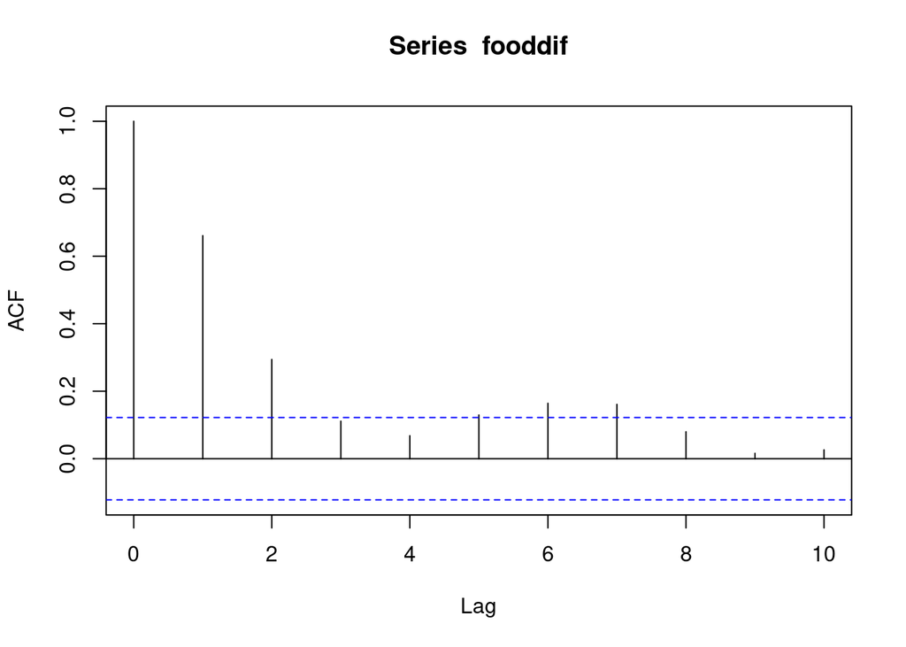

```r
foodacf = acf(fooddif, lag.max = 10)
```

### Empirical PACF after differencing

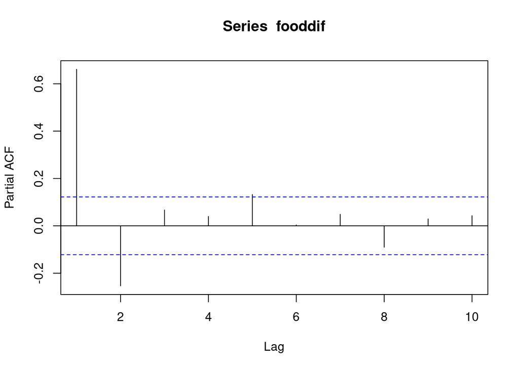

```r
foodpacf = pacf(fooddif, lag.max = 10)
```

### auto.ARIMA(1, 1, 1)

```r
foodsel = foodcorp.df[,c(8)]
tsfoodsel = as.ts(foodsel)
auto.arima(tsfoodsel, test = c("adf"), trace = TRUE)
```

```
##
##  Fitting models using approximations to speed things up...
##
##  ARIMA(2,1,2) with drift         : 3226.352
##  ARIMA(0,1,0) with drift         : 3385.59
##  ARIMA(1,1,0) with drift         : 3238.19
##  ARIMA(0,1,1) with drift         : 3246.874
##  ARIMA(0,1,0)                    : 3405.015
##  ARIMA(1,1,2) with drift         : 3223.556
##  ARIMA(0,1,2) with drift         : 3227.294
##  ARIMA(1,1,1) with drift         : 3221.757
##  ARIMA(2,1,1) with drift         : 3224.271
##  ARIMA(2,1,0) with drift         : 3223.247
##  ARIMA(1,1,1)                    : 3225.001
##
##  Now re-fitting the best model(s) without approximations...
##
##  ARIMA(1,1,1) with drift         : 3232.205
##
##  Best model: ARIMA(1,1,1) with drift
```

```
## Series: tsfoodsel
## ARIMA(1,1,1) with drift
##
## Coefficients:
##          ar1     ma1    drift
##       0.4709  0.3770  50.3061
## s.e.  0.0766  0.0804  20.1535
##
## sigma^2 estimated as 15793:  log likelihood=-1612.02
## AIC=3232.05   AICc=3232.21   BIC=3246.26
```